# Assignment 7: Visualization - Some aspects of ggplot2

*How to do it?*:

- Open the Rmarkdown file of this assignment (link) in Rstudio.
- Right under each **question**, insert a code chunk (you can use the hotkey `Ctrl + Alt + I` to add a code chunk) and code the solution for the question.
- `Knit` the rmarkdown file (hotkey: `Ctrl + Alt + K`) to export an html.
- Publish the html file to your Githiub Page.

*Submission*: Submit the link on Github of the assignment to Canvas

Use the data of your own. Produce the following types of plots and comment on each plot. Plots should be meaningful. If you use the data we used in class, make sure the plots are not the same as the ones in the slides. All plots should have title, caption, appropriate labels on x and y-axis.

```r
library(tidyverse)
library(lubridate)
df <- read_csv("titanic.csv")
colnames(df)
```

```
##  [1] "PassengerId" "Survived"    "Pclass"      "Name"        "Sex"
##  [6] "Age"         "SibSp"       "Parch"       "Ticket"      "Fare"
## [11] "Cabin"       "Embarked"
```

1. Make a plot using `facet_wrap` by one categorical variable (`facet_wrap(~variable1)`)

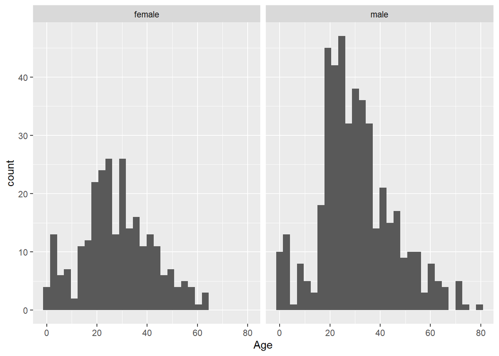

```r
library(ggplot2)
df %>% ggplot()+
  geom_histogram(mapping=aes(x=Age))+
  facet_wrap(~Sex)
```

2. Make a plot using `facet_wrap` by two categorical variables (`facet_wrap(~variable1+variable2)`)

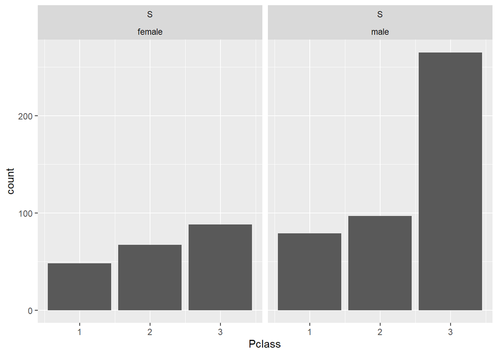

```r
df %>% filter(Embarked == "S") %>% ggplot()+
  geom_bar(mapping=aes(x=Pclass))+
  facet_wrap(~Embarked+Sex)
```

3. Make a plot using `position ='dodge'`.

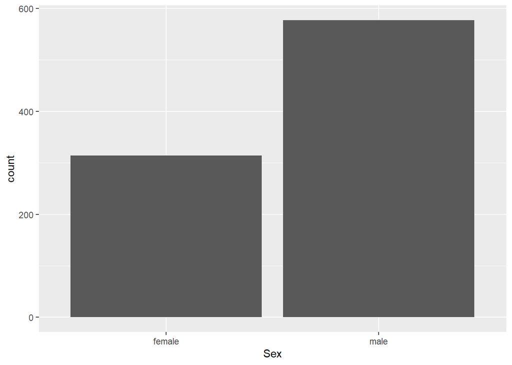

```r
df %>% ggplot()+
  geom_bar(mapping=aes(x=Sex), position = 'dodge')
```

4. Make a plot using `position ='fill'`.

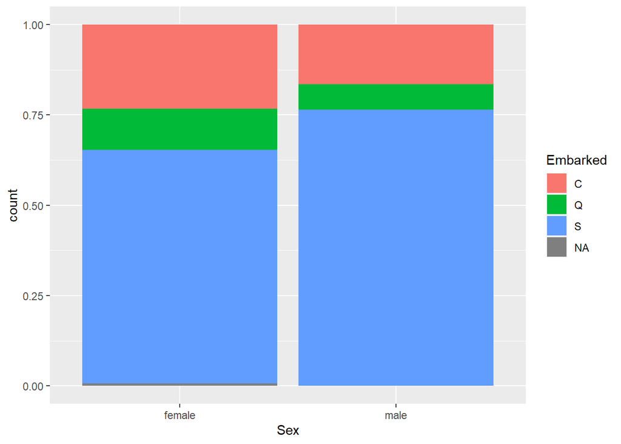

```r
df %>% ggplot()+
  geom_bar(mapping=aes(x=Sex,fill=Embarked), position = 'fill')
```

5. Make a plot using `geom_col`.

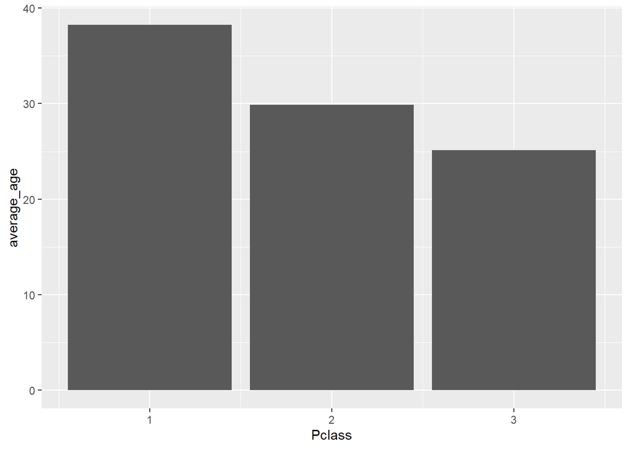

```r
df %>% group_by(Pclass) %>%
  summarise(average_age=mean(Age, na.rm=TRUE)) %>%
  ggplot()+
  geom_col(mapping=aes(x=Pclass, y=average_age))
```

6. Change the theme of one of your plots.

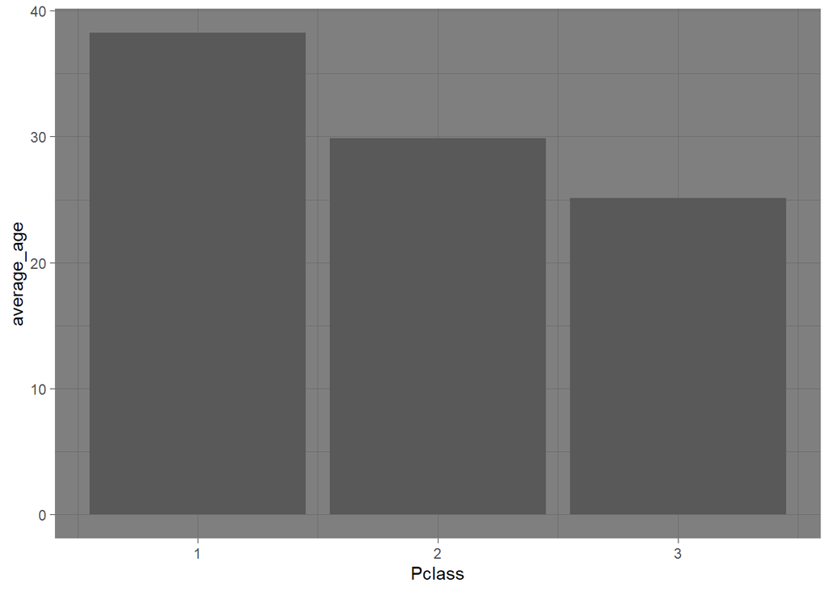

```r
df %>% group_by(Pclass) %>%
  summarise(average_age=mean(Age, na.rm=TRUE)) %>%
  ggplot()+
  geom_col(mapping=aes(x=Pclass, y=average_age)) + theme_dark()
```

7. Make a plot using combo filter + ggplot

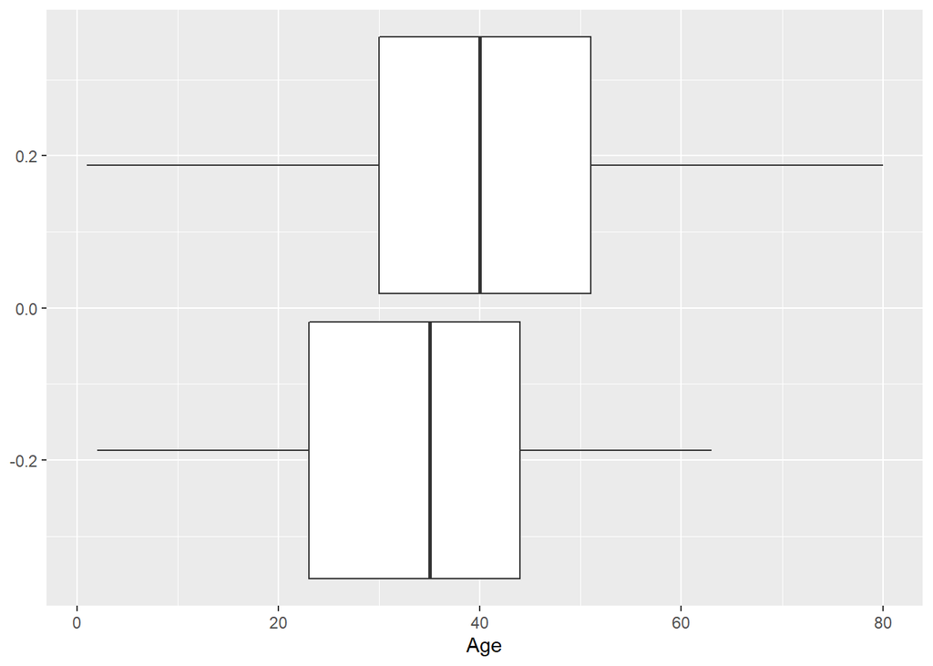

```r
df %>% filter(Pclass == 1) %>%
  ggplot()+
  geom_boxplot(mapping=aes(x=Age,group=Sex))
```

8. Make a plot using combo group_by + summarise + geom_col

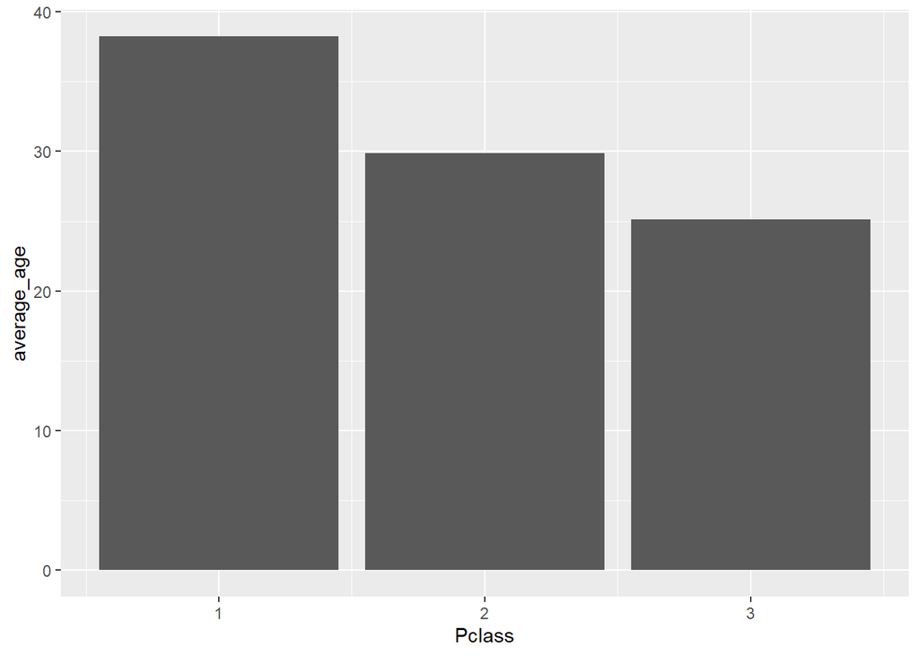

```r
df %>% group_by(Pclass) %>%
  summarise(average_age=mean(Age, na.rm=TRUE)) %>%
  ggplot()+
  geom_col(mapping=aes(x=Pclass, y=average_age))
```

```r
plot7 <- df %>% ggplot()+
  geom_bar(mapping=aes(x=Sex,fill=Embarked), position = 'fill')
ggsave(filename = 'plot7.png', plot = plot7)
```

10. In this question, we will use the Covid19 vaccination data for the US. The data and data dictionary can be found at the below link:
- [Data](https://raw.githubusercontent.com/owid/covid-19-data/master/public/data/vaccinations/vaccinations-by-manufacturer.csv)

```r
library(tidyverse)
df <- read_csv('https://raw.githubusercontent.com/owid/covid-19-data/master/public/data/vaccinations/vaccinations-by-manufacturer.csv')
```

`Geom_point` makes scatter plots, which plot two numeric (or Date) variables. A third categorical variable is often brought in for color. For example, we can compare different vaccine types used in the US by

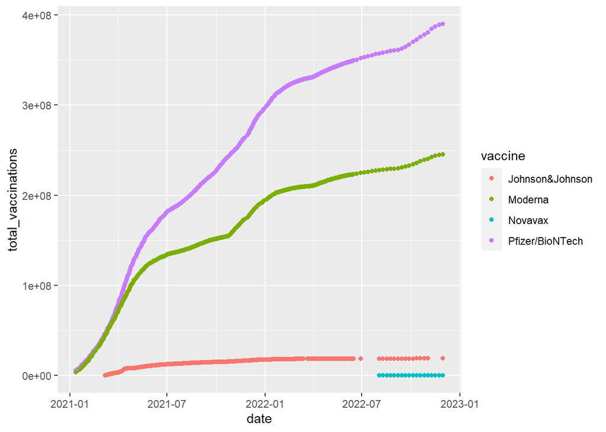

```r
df %>%
  filter(location=='United States') %>%
  ggplot()+
  geom_point(mapping = aes(x = date,
                                    y = total_vaccinations,
                                    color = vaccine))
```

Do the follows.

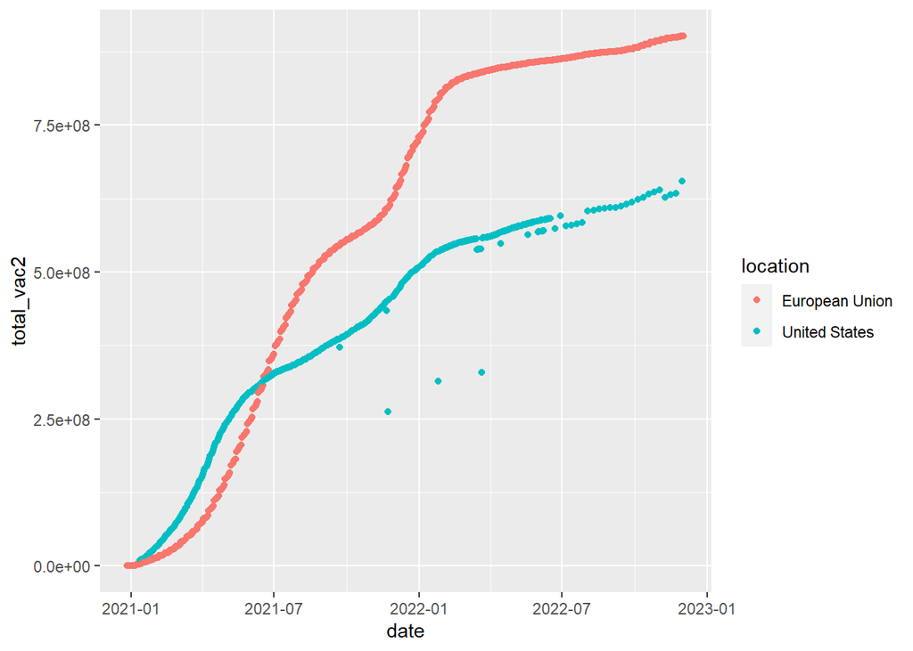

```r
# the total vaccines (including all types of vaccines) by date
d1 <- df %>%
  filter(location %in% c('United States', 'European Union')) %>%
  group_by(date, location) %>%
  summarise(total_vac2=sum(total_vaccinations, na.rm=TRUE))

# Plot
d1 %>%
  ggplot()+
  geom_point(mapping=aes(x=date,
                         y=total_vac2,
                         color=location))
```

Notice that the above codes could be piped in one

```r
df %>%
  filter(location %in% c('United States', 'European Union')) %>%
  group_by(date, location) %>%
  summarise(total_vac2=sum(total_vaccinations, na.rm=TRUE)) %>%
  ggplot()+
  geom_point(mapping=aes(x=date,
                         y=total_vac2,
                         color=location))
```

Do the follows.

- Use `geom_point` compare the total vaccines (including all types of vaccines) by date between countries/regions in Asia

```r
table(df$location)
```

```
##
##      Argentina        Austria        Belgium       Bulgaria         Canada
##           3431            441            395            330            255
##          Chile        Croatia         Cyprus        Czechia        Denmark
##           1504            390            343           2793            385
##        Ecuador        Estonia European Union        Finland         France
##           1161            378           7060            257           2601
##        Germany      Hong Kong        Hungary        Iceland        Ireland
##           2987           1255            481            151            430
##          Italy          Japan         Latvia  Liechtenstein      Lithuania
##           2335           1720           2006            193            340
##     Luxembourg          Malta          Nepal    Netherlands         Norway
##            353            347            486            324            374
##           Peru         Poland       Portugal        Romania       Slovakia
##           2072            437            675           1715            408
##       Slovenia   South Africa    South Korea          Spain         Sweden
##            354            498           2724            320            264
##    Switzerland        Ukraine  United States        Uruguay
##           1871           1491           1466           1224
```

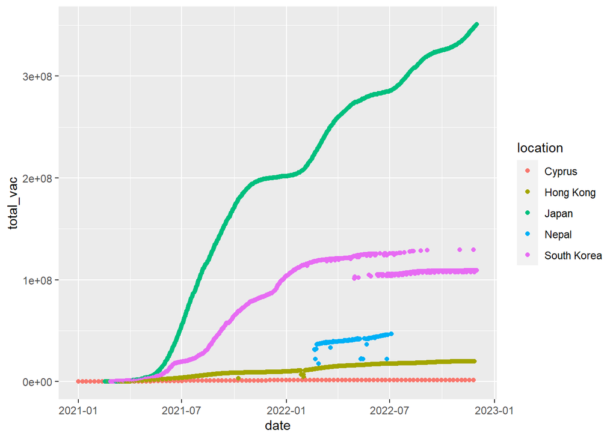

```r
df %>%
  filter(location %in% c('Japan', 'Nepal', 'Cyprus', 'Hong Kong', 'South Korea')) %>%
  group_by(date, location) %>%
  summarise(total_vac=sum(total_vaccinations, na.rm=TRUE)) %>%
  ggplot()+
  geom_point(mapping=aes(x=date,
                         y=total_vac,
                         color=location))
```

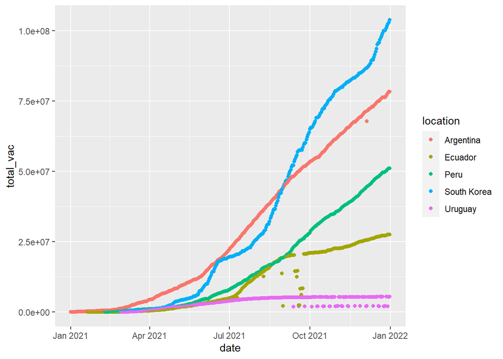

```r
df %>%
  filter(location %in% c('Argentina', 'Peru', 'Ecuador', 'Uruguay', 'South Korea'), date<'2022-01-01', date>='2021-01-01') %>%
  group_by(date, location) %>%
  summarise(total_vac=sum(total_vaccinations, na.rm=TRUE)) %>%
  ggplot()+
  geom_point(mapping=aes(x=date,
                         y=total_vac,
                         color=location))
```